# MCBD Results

Ciara Hovis, CSIS Lab, Michigan State University

6 October 2020 (Updated 7 Octobter 2020)

# 1. Summary

Synthesis of survey 2 and 3 results for metacoupling/biodiversity systematic review. It consists of response summaries and visualizations of the accepted papers.

# 2. R Setup

The script presented here was done using R (version 4.0.2; R Core Team 2020) and its packages.

Load libraries, directories, and custom functions from source file.

# 3. Load data

```r
# surveys
  ab_screen <- read.csv(paste0(dat.dir, 'absScreening\\AbsScreen1_Merge.csv'))
  ab_maybes <- read.csv(paste0(dat.dir, 'absScreening\\AbsScreen2_maybes_to_keep.csv'))
  ab_yeses <- read.csv(paste0(dat.dir,  'absScreening\\final_sample_for_coding.csv'))
  assignments <- read.csv(paste0(dat.dir,'absScreening\\Coding_MergeAssign_R1.csv'))


  survey1 <- read.csv(paste0(dat.dir,'survey1_cleaned.csv'))
  s2 <- read.csv(paste0(dat.dir,'survey2_cleaned.csv'))
  survey3 <- read.csv(paste0(dat.dir,'survey3_cleaned.csv'))
  s23 <- read.csv(paste0(dat.dir,'s23.csv'))
# factor format
  s23$maj_eff<-factor(s23$maj_eff, c("Beneficial","Detrimental","Changed", "Mixed","Not significant or unclear"))
  s23_maj <- s23[!duplicated(s23$paper_id),]
```

# 4. Survey 1 & 2 Results

## 4.1 Sample Results

Accepted/rejected published papers over time

Total number of papers at the coding stage = 591

```r
# get total numbers but also ensure both values here match
  nrow(survey1)
  length(unique(survey1$paper_id))
```

```
## [1] 591
## [1] 591
```

Number of accepted and rejected papers.

Accepted = 131 (22%) , Rejected = 460 (78%)

```r
# get summary
  ddply(survey1, .(status), summarize,
        # total count of entries
        count=length(status))
sum(survey1$status == 'accept')/nrow(survey1)
sum(survey1$status == 'reject')/nrow(survey1)
```

| status | count |
| --- | --- |
| accept | 131 |
| reject | 460 |

```
## [1] 0.2216582
## [1] 0.7783418
```

Visualizing accepted papers over time, including the ones from the abstract screening process.

```r
# all abstract screened papers (n=7306)
  ab_screen <- ab_screen[!ab_screen$PY==2020,] #remove 2020 studies
  ab_all <- ab_screen[!duplicated(ab_screen$TITLE),];nrow(ab_all)

# remove the papers accepted in screening from the abstract screening list (n=6665)
  ab_reject <- anti_join(ab_all,ab_maybes,by=c("TITLE"))
  ab_reject <- anti_join(ab_reject,ab_yeses,by=c("TITLE"))
  ab_reject <- ab_reject[!duplicated(ab_reject$TITLE,ab_reject$PY),];nrow(ab_reject)

# all papers that were accepted from abstract screening (n=641)
  ab_accept <- ab_yeses[!duplicated(ab_yeses$TITLE),]


# accepted papers from the assignment list for full review (n=595)
  papers_reviewed <- assignments[!duplicated(assignments$TITLE),]

# papers with PDF not available or rejected because of language (n=46)
  paper_unavail <- anti_join(ab_accept,papers_reviewed,by=c("TITLE"))
  paper_unavail <- paper_unavail[!duplicated(paper_unavail$TITLE),]

# rejected papers or not yet reviewed (n=460)

  keep <-  subset(survey1, status=='accept')
  reject <- anti_join(survey1,keep)

  papers_rejected <- anti_join(papers_reviewed,keep,by=c("STUDY_ID.1"="paper_id"))
  papers_rejected <- papers_rejected[!duplicated(papers_rejected$TITLE),]
```

```
## [1] 7306
## [1] 6665
```

```r
# show numbers:
  paste('original number of papers in WOS search:',nrow(ab_screen))
  paste('number of duplicates in WOS search:',nrow(ab_screen)-nrow(ab_all))
  paste('number of abstracts screened:',nrow(ab_all))
  paste('number of accepted abstracts:',nrow(ab_accept))
  paste('number of rejected abstracts:',nrow(ab_reject))
  paste('number of accepted papers unavailable or non-English:',
        nrow(paper_unavail))
  paste('number of papers available for full review:',
        nrow(papers_reviewed))
  paste('number of full papers accepted for synthesis:',
        nrow(keep))
  paste('number of full papers rejected from synthesis:',nrow(reject))
  paste('number of full papers not yet reviewed for synthesis:',
        nrow(papers_rejected)-nrow(reject)-5)

# num of full papers not yet reviewed is -1, idk why. Maybe due to common papers? The check below is True so I'm not worried.


# test if they add up correctly
  paste('COUNT TESTS:')
  paste('total full papers:',
        nrow(papers_reviewed) == nrow(ab_accept) - nrow(paper_unavail))
  paste('total abstract screen:',
        nrow(ab_all) == nrow(ab_reject) + nrow(ab_accept))
```

```
## [1] "original number of papers in WOS search: 7318"
## [1] "number of duplicates in WOS search: 12"
## [1] "number of abstracts screened: 7306"
## [1] "number of accepted abstracts: 641"
## [1] "number of rejected abstracts: 6665"
## [1] "number of accepted papers unavailable or non-English: 46"
## [1] "number of papers available for full review: 595"
## [1] "number of full papers accepted for synthesis: 131"
## [1] "number of full papers rejected from synthesis: 460"
## [1] "number of full papers not yet reviewed for synthesis: -1"
## [1] "COUNT TESTS:"
## [1] "total full papers: TRUE"
## [1] "total abstract screen: TRUE"
```

Next, simplify columns and combine for three tiers in the plot.

```r
# select columns
  # papers found in WOS but don't meet criteria
    reject_abstract_level <- subset(ab_reject,select=c("STUDY_ID","PY"))
  # WOS papers that meet criteria but don't directly look at coupling effects on biodiv
    reject_paper_level <- subset(papers_rejected,select=c("STUDY_ID.1","PY"))
    reject_paper_level2 <- subset(paper_unavail,select=c("STUDY_ID","PY"))
  # papers that do look at coupling effects on biodiv
    accept_paper_level <- subset(keep,select=c("paper_id","year_pub"))

# rename columns
  colnames(reject_abstract_level) <- c('paper_id','year_pub')
  colnames(reject_paper_level) <- c('paper_id','year_pub')
  colnames(reject_paper_level2) <- c('paper_id','year_pub')

# add columns
  #papers that discuss tc effects on biodiv in...
  reject_abstract_level$type <- 'search but not abstract'
  reject_paper_level$type <- 'abstract but not paper'
  reject_paper_level2$type <- 'abstract but not paper'
  accept_paper_level$type <- 'abstract and paper'

# rbind (should be 7307 rows)
  papers <- rbind(reject_abstract_level,reject_paper_level,
                  reject_paper_level2, # <-- NOT SURE IF UNAVAILABLE PAPERS BELONG HERE
                  accept_paper_level)

# check
  nrow(papers)
```

```
## [1] 7306
```

Plot image.

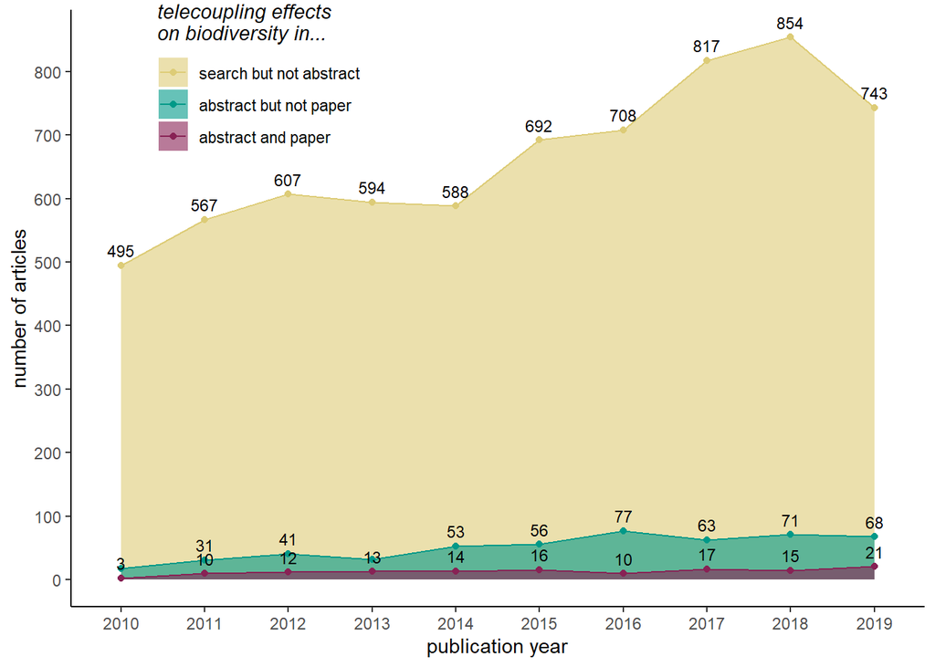

```r
# Get a count of records per year
  paper_ct <- ddply(papers, .(year_pub,type), summarize, count=length(year_pub))

# Change to factors
  paper_ct$year_pub <- as.factor(paper_ct$year_pub)
  paper_ct$type <- factor(paper_ct$type,
                        levels = c('search but not abstract',
                                   'abstract but not paper',
                                   'abstract and paper'))

  papers.fig <- ggplot(paper_ct, aes(x=year_pub, y=count)) +
                  geom_area(position="identity",
                            aes(y=count, fill = type, group = type), alpha=0.6) +
                  geom_point(aes(y =count, color = type, group = type))+
                  geom_line(aes(y =count, color = type, group = type))+
                  geom_text(aes(label=count),size=3,
                            position=position_dodge(.7),
                            vjust=-.7,
                            check_overlap=TRUE)+
                  scale_color_manual(
                  name=expression(italic("telecoupling effects\non biodiversity in...")),
                  values=paper_col)+
                  scale_fill_manual(
                  name=expression(italic("telecoupling effects\non biodiversity in...")),
                  values=paper_col)+
                  xlab("publication year")+
                  ylab("number of articles") + ylim(0,860)+
                  scale_y_continuous(breaks=seq(0,850,100)) +
                  theme_classic()+
                  theme(legend.position = c(0.22,0.87))

# show here
  papers.fig
```

Acceptance rate for abstract screening.

```r
# get total abstract acceptance rate
  sum(ab_all$INCLUDE=='YES')/nrow(ab_all)
```

```
## [1] 0.08007117
```

Acceptance rate for papers that were reviewed (**NOTE:** this includes the 5 common surveys).

```r
# get total paper acceptance rate
  sum(survey1$status=='accept')/nrow(survey1)
```

```
## [1] 0.2216582
```

Acceptance rate per person (**NOTE:** this excludes the 5 common surveys per person, but has a rate for it on its own as “all”).

```r
# get summary
  acr <- ddply(survey1, .(coder_id), summarize,
              # total count of entries
              count=length(coder_id),
              accept=sum(status=='accept'),
              reject=sum(status=='reject'),
              # percent acceptance
              accept_rate=sum(status=='accept')/length(coder_id))
  acr
```

| coder_id | count | accept | reject | accept_rate |
| --- | --- | --- | --- | --- |
| A_Herzberger | 63 | 20 | 43 | 0.3174603 |
| A_Torres | 51 | 7 | 44 | 0.1372549 |
| all | 5 | 4 | 1 | 0.8000000 |
| C_Hovis | 92 | 19 | 73 | 0.2065217 |
| E_Dean | 43 | 7 | 36 | 0.1627907 |
| E_Xing | 43 | 9 | 34 | 0.2093023 |
| K_Kapsar | 52 | 11 | 41 | 0.2115385 |
| M_Lei | 43 | 15 | 28 | 0.3488372 |
| MG_Chung | 43 | 5 | 38 | 0.1162791 |
| X_Wu | 67 | 18 | 49 | 0.2686567 |

[output cut: 3 more lines]

Average per-person acceptance rates

```r
# mean per-person acceptance rate
  mean(acr$accept_rate)
```

```
## [1] 0.2392594
```

## 4.2 General Results

Counts of papers that were inferred (accepted papers only)

Total rate of **inferring** across papers.

```r
# get total papers for which the tc relationships were inferred
  paste('number inferred papers:',sum(keep$explicit_distant_impacts=='No'))
  paste('number explicit papers:',sum(keep$explicit_distant_impacts=='Yes'))

# get total inferring rate
  paste('inferred percent:',sum(keep$explicit_distant_impacts=='No')/nrow(keep))
  paste('explicit percent:',sum(keep$explicit_distant_impacts=='Yes')/nrow(keep))
```

```
## [1] "number inferred papers: 46"
## [1] "number explicit papers: 76"
## [1] "inferred percent: 0.351145038167939"
## [1] "explicit percent: 0.580152671755725"
```

Percent of papers inferred per person per person

```r
# get summary
  ddply(keep, .(coder_id), summarize,
        # total count of entries
        count=length(coder_id),
        inferred=sum(explicit_distant_impacts=='No'),
        explicit=sum(explicit_distant_impacts=='Yes'),
        # percent inferred
        inferred_rate=sum(explicit_distant_impacts=='No')/length(coder_id))
```

| coder_id | count | inferred | explicit | inferred_rate |
| --- | --- | --- | --- | --- |
| A_Herzberger | 20 | 9 | 11 | 0.4500000 |
| A_Torres | 7 | 2 | 5 | 0.2857143 |
| all | 4 | 2 | 2 | 0.5000000 |
| C_Hovis | 19 | 5 | 14 | 0.2631579 |
| E_Dean | 7 | 2 | 5 | 0.2857143 |
| E_Xing | 9 | 0 | 0 | 0.0000000 |
| K_Kapsar | 11 | 7 | 4 | 0.6363636 |
| M_Lei | 15 | 6 | 9 | 0.4000000 |
| MG_Chung | 5 | 1 | 4 | 0.2000000 |
| X_Wu | 18 | 2 | 16 | 0.1111111 |

[output cut: 2 more lines]

Counts of study types (accepted papers only)

```r
# get summary
  ddply(keep, .(C4_study), summarize,
        # total count of entries
        count=length(C4_study),
        percent=length(C4_study)/nrow(keep))
```

| C4_study | count | percent |
| --- | --- | --- |
| Experimental study | 3 | 0.022900763 |
| Modeling study (using empirical data and not projected) | 11 | 0.083969466 |
| Observational study | 116 | 0.885496183 |
| Observational/Modeling study | 1 | 0.007633588 |

Habitat Frequency (study level, n= 131)

```r
habitat.study <- count(s2, 'habitat')
print(habitat.study)
prop.table(table(s2$habitat))
```

```
##                      habitat freq
## 1                 Freshwater   22
## 2          Freshwater;Marine    1
## 3                     Marine   25
## 4 Not specified/Global study    2
## 5                Terrestrial   75
## 6     Terrestrial;Freshwater    4
## 7         Terrestrial;Marine    2
##
##                 Freshwater          Freshwater;Marine
##                0.167938931                0.007633588
##                     Marine Not specified/Global study
##                0.190839695                0.015267176
##                Terrestrial     Terrestrial;Freshwater
##                0.572519084                0.030534351
##         Terrestrial;Marine
##                0.015267176
```

Taxa Frequency (study level, n=131)

```r
desired_length <- 8
empty_list <- vector(mode = "list", length = desired_length)

taxa <- (s2$taxa)
table(taxa)
taxa.list <- c('Mammals', 'Plants', 'Reptiles', 'Amphibians', 'Birds', 'Fish', 'Invertebrates', 'Other')
taxa.count <- empty_list

for (i in 1:length(taxa.list)) {

  taxa.count[i] <- sum(str_count(taxa, taxa.list[i]))
    }

taxa.count <- rbind(taxa.list,taxa.count)
taxa.count

multiple <- str_count(taxa, ';')
multiple <- multiple != 0
multiple <- table(multiple) ["TRUE"]
multiple

# Others? Not a big deal since taxa is clarified in survey 3.Not a big deal.

othTaxa <- s2[which(s2$taxa == 'Other'),]
```

```
## taxa
##                              Amphibians; Plants
##                                               1
##                                           Birds
##                                              36
##                                  Birds; Mammals
##                                               1
##              Birds; Mammals; Amphibians; Plants
##                                               1
## Birds; Mammals; Reptiles; Invertebrates; Plants
##                                               1
##                                 Birds; Reptiles
##                                               1
##                                            Fish
##                                              14
##                             Fish; Invertebrates
##                                               1
##                                   Invertebrates
##                                              23
##                           Invertebrates; Plants
##                                               2
##                            Invertebrates;Plants
##                                               1
##                                         Mammals
##                                              14
##    Mammals; Reptiles; Amphibians; Invertebrates
##                                               1
##                                           Other
##                                               3
##                                          Plants
##                                              26
##                       Plants; habitat pollution
##                                               1
##                                        Reptiles
##                                               3
##                             Reptiles;Amphibians
##                                               1
##            [,1]      [,2]     [,3]       [,4]         [,5]    [,6]
## taxa.list  "Mammals" "Plants" "Reptiles" "Amphibians" "Birds" "Fish"
## taxa.count 18        33       7          4            40      15
##            [,7]            [,8]
## taxa.list  "Invertebrates" "Other"
## taxa.count 29              3
## TRUE
##   12
```

Flow frequency (study level, n=131)

```r
desired_length <- 10
empty_list <- vector(mode = 'list', length = desired_length)

tc <- s2$tele_cat
tc.list <-c("Energy Transfer","Investment","Knowledge Transfer",
                                 "Migration (human)","Migration (non-human)",
                                 "Species Dispersal","Tourism","Trade","Waste Transfer","Water Transfer")
tc.count <- empty_list

for (i in 1:length(tc.list)) {

  tc.count[i] <- sum(str_count(tc, tc.list[i]))
    }

tc.count <- rbind(tc.list,tc.count)
tc.count


# Can't get loop to count the migration values for some reason, manual input code below
# Migration (human) n=4     # Migration (non-human) n=0
tc.table <- table(s2$tele_cat)

tc.count[2,4] <- tc.table[5] + tc.table[13]      # Migration (human) n=6     # Migration (non-human) n-7

tc.count

#gather(tc.count)

multiple <- str_count(tc, ';')
multiple <- multiple != 0
multiple <- table(multiple) ["TRUE"]
multiple
```

```
##          [,1]              [,2]         [,3]
## tc.list  "Energy Transfer" "Investment" "Knowledge Transfer"
## tc.count 9                 8            13
##          [,4]                [,5]                    [,6]
## tc.list  "Migration (human)" "Migration (non-human)" "Species Dispersal"
## tc.count 0                   0                       17
##          [,7]      [,8]    [,9]             [,10]
## tc.list  "Tourism" "Trade" "Waste Transfer" "Water Transfer"
## tc.count 57        34      2                4
##          [,1]              [,2]         [,3]
## tc.list  "Energy Transfer" "Investment" "Knowledge Transfer"
## tc.count 9                 8            13
##          [,4]                [,5]                    [,6]
## tc.list  "Migration (human)" "Migration (non-human)" "Species Dispersal"
## tc.count 4                   0                       17
##          [,7]      [,8]    [,9]             [,10]
## tc.list  "Tourism" "Trade" "Waste Transfer" "Water Transfer"
## tc.count 57        34      2                4
## TRUE
##   16
```

Number of metrics reported by each paper

```r
# get summary
  ddply(survey3, .(paper_id), summarize,
        # total count of entries
        num_entries=length(entry_id),
        perc_dataset=length(entry_id)/nrow(survey3),
        num_taxa=length(unique(taxa))) %>%
    arrange(desc(perc_dataset))

num.metric <- count(survey3$paper_id)
range(num.metric$freq)
sum(num.metric$freq)
```

| paper_id | num_entries | perc_dataset | num_taxa |
| --- | --- | --- | --- |
| 84 | 162 | 0.221614227 | 1 |
| 4060 | 57 | 0.077975376 | 1 |
| 1551 | 27 | 0.036935705 | 1 |
| 3772 | 22 | 0.030095759 | 1 |
| 6502 | 21 | 0.028727770 | 1 |
| 134 | 20 | 0.027359781 | 1 |
| 4155 | 20 | 0.027359781 | 1 |
| 4552 | 15 | 0.020519836 | 1 |
| 479 | 14 | 0.019151847 | 1 |
| 3112 | 13 | 0.017783858 | 1 |

[output cut: 117 more lines]

```
## [1]   1 162
## [1] 731
```

Number of metrics by taxa and paper

```r
# get summary
  a <- ddply(survey3, .(taxa), summarize,
        # total count of entries
        num_entries=length(entry_id),
        perc_dataset=length(entry_id)/nrow(survey3),
        num_papers=length(unique(paper_id)),
        perc_papers=length(unique(paper_id))/length(unique(survey3$paper_id))) %>%
      arrange(desc(perc_dataset))

# view
  a
```

| taxa | num_entries | perc_dataset | num_papers | perc_papers |
| --- | --- | --- | --- | --- |
| Birds | 340 | 0.465116279 | 36 | 0.283464567 |
| Invertebrates | 159 | 0.217510260 | 28 | 0.220472441 |
| Plants/Trees/Shrubs | 85 | 0.116279070 | 30 | 0.236220472 |
| Fish | 75 | 0.102599179 | 15 | 0.118110236 |
| Mammals | 45 | 0.061559508 | 13 | 0.102362205 |
| Multiple | 17 | 0.023255814 | 5 | 0.039370079 |
| Reptiles | 9 | 0.012311902 | 4 | 0.031496063 |
| Amphibians | 1 | 0.001367989 | 1 | 0.007874016 |

## 4.3 Biodiversity and Flow Categories by Country

Biodiversity country map

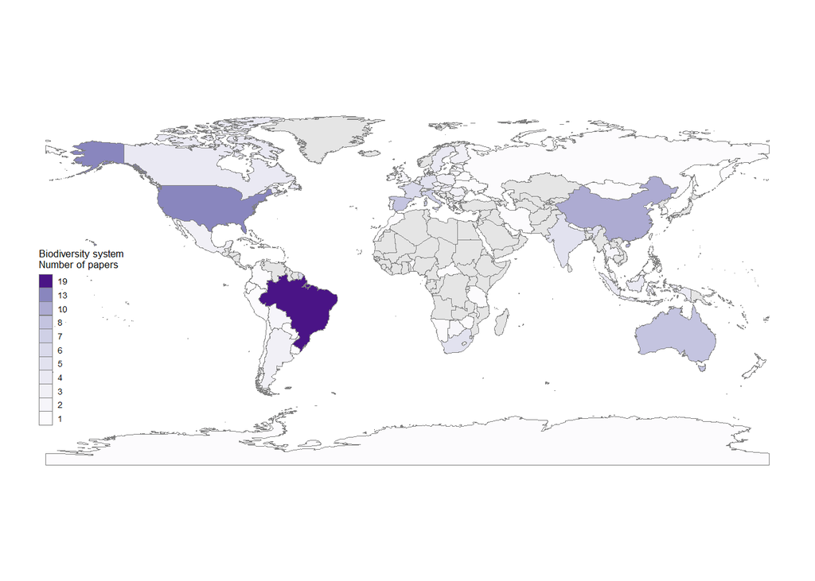

```r
shp <- ne_countries(scale = 50, returnclass = 'sf') %>% #st_as_sf() %>%
  select(name, iso_a3) %>% ## , economy, income_grp
  # filter(name != 'Antarctica') %>%
  # filter(name == 'France') %>%
  dplyr::mutate(
    iso_a3 = if_else(name == 'France', 'FRA', iso_a3),
    iso_a3 = if_else(name == 'Norway', 'NOR', iso_a3))
# plot(shp[1])

shp %>% filter(name == 'Norway')

### add new country name that are consistant with names uned in SDG data
# library(readxl)
# xls.shp.info <- paste0(dir, '/update_0503_SUM_dist/_input_data/ne_10m_admin_0_countries/Table/ne_10m_admin_0_countries-Export_Output.xls')
#
# nation_new_name <-
#   read_excel(path = xls.shp.info,
#              sheet = "dat", col_names = T) %>%
#   select(ADMIN, ADM0_A3, nation_name)
# names(nation_new_name)
# nation_new_name <- as.data.frame(nation_new_name[,-c(3,4)])




### theme, font --------------------------------------------------------------------------------------
font      <- 'sans' ## = "TT Arial"
font_size <- 6.5 ## max = 7; min = 5 for Nature Sustainability
map_theme <- ggpubr::theme_transparent()+
  theme(
    axis.title.x=element_blank(),
    axis.title.y=element_blank(),
    axis.text.x=element_blank(),
    axis.ticks = element_blank(),
    panel.grid.major = element_blank(),
    panel.grid.minor = element_blank(),
    panel.border = element_blank(),
    legend.position = c(0.09, 0.38),
    legend.key.size = unit(0.3, "cm"),
    # legend.key.height = unit(0.5, "cm"),
    legend.key = element_rect(fill = NA, colour = NA, size = 0.25),

    panel.background = element_rect(fill = "transparent", colour = NA),
    plot.background = element_rect(fill = "transparent", colour = NA),
    legend.background = element_rect(fill = "transparent", colour = NA),
    legend.box.background = element_rect(fill = "transparent", colour = NA),
    text=element_text(family=font, size=font_size))


### - Read in Data

df99 <- read.csv(paste0(dat.dir, 'survey2_cleaned.csv'))


### - list_countries
ctr_sys <- df99 %>%
  select(paper_id, list_countries) %>%
  data.frame(., do.call(rbind, str_split(.$list_countries,';'))) %>%
  gather(key = 'key', value = list_countries, 3:ncol(.)) %>%
  dplyr::mutate(list_countries = trimws(list_countries)) %>%
  dplyr::distinct(paper_id, list_countries, .keep_all = T) %>%
  filter(list_countries != '') %>%
  arrange(paper_id) %>%
  group_by(list_countries) %>%
  tally()%>%
  arrange(desc(n)) #%>%
# str(ctr_sys)


### join new name table
shp_df <- shp %>%
  left_join(., ctr_sys, by=c("iso_a3" = "list_countries"))

### check the join
shp_df_check <- merge(
  shp, ctr_sys, by.x = "iso_a3", by.y = "list_countries", all.y=T) %>%
  st_drop_geometry()

# str(shp_df)
unique(shp_df$n)


### breaks and colors
var <- shp_df$n
max <- max(var, na.rm = T); max
min <- min(var, na.rm = T); min

breaks <- seq(min, max, 2); breaks; length(breaks)
breaks <- sort(unique(shp_df$n)); breaks; length(breaks)
myPalette <- colorRampPalette((brewer.pal(8, "Greens")));# myPalette; rev
colors <- myPalette(length(breaks)); colors
title <- 'Entire system\nNumber of papers'


### - biodiv_countries
ctr_bio <- df99 %>%
  select(paper_id, biodiv_countries) %>%
  data.frame(., do.call(rbind, str_split(.$biodiv_countries,';'))) %>%
  gather(key = 'key', value = biodiv_countries, 3:ncol(.)) %>%
  dplyr::mutate(biodiv_countries = trimws(biodiv_countries)) %>%
  dplyr::distinct(paper_id, biodiv_countries, .keep_all = T) %>%
  filter(biodiv_countries != '') %>%
  arrange(paper_id) %>%
  group_by(biodiv_countries) %>%
  tally()%>%
  arrange(desc(n)) #%>%
# str(ctr_bio)


### join new name table
shp_df <- shp %>%
  left_join(., ctr_bio, by=c("iso_a3" = "biodiv_countries"))

# str(shp_df)
unique(shp_df$n)

### check the join
shp_df_check <- shp %>%
  right_join(., ctr_bio, by=c("iso_a3" = "biodiv_countries"))

### breaks and colors
var <- shp_df$n
max <- max(var, na.rm = T); max
min <- min(var, na.rm = T); min

breaks <- seq(min, max, 2); breaks; length(breaks)
breaks <- sort(unique(shp_df$n)); breaks; length(breaks)
myPalette <- colorRampPalette((brewer.pal(8, "Purples")));# myPalette; rev
colors <- myPalette(length(breaks)); colors
title <- 'Biodiversity system\nNumber of papers'

### plot
fig2 <- ggplot(data = shp_df) +
  geom_sf(aes(fill = n), color='gray50', size=0.01) +
  scale_fill_gradientn(
    name = title,
    colours= colors, na.value = "gray90",
    limits = c(min,max), breaks = breaks) +
  guides(fill = guide_legend(label.hjust = 0, label = T,
                             reverse = T, title = title))+
  map_theme
fig2
```

```r
dir
fname <- paste0(fig.dir, 'Fig_map_country_bio.jpg'); fname
```

|  | name | iso_a3 | geometry |
| --- | --- | --- | --- |
| 1 | Norway | NOR |  |

```
##  [1] NA  3  2  9  4  1 18 11  5  8  6  7 13
## [1] 18
## [1] 1
## [1]  1  3  5  7  9 11 13 15 17
## [1] 9
##  [1]  1  2  3  4  5  6  7  8  9 11 13 18
## [1] 12
##  [1] "#F7FCF5" "#EBF7E7" "#DCF1D7" "#C9EAC2" "#B2E0AB" "#98D594" "#7CC77C"
##  [8] "#5CB86A" "#3EA85A" "#2B934B" "#16793E" "#005A32"
##  [1] NA  1  3  8  2 19  4 10  5  6  7 13
## [1] 19
## [1] 1
##  [1]  1  3  5  7  9 11 13 15 17 19
## [1] 10
##  [1]  1  2  3  4  5  6  7  8 10 13 19
## [1] 11
##  [1] "#FCFBFD" "#F2F1F7" "#E6E5F1" "#D6D7E9" "#C2C2DF" "#ADABD2" "#9794C5"
##  [8] "#827FBB" "#7262AC" "#603E9A" "#4A1486"
## [1] "C:/Users/Ciara Hovis/Desktop/GradSchool/Co-author papers/MetaBD/MCBD_Root"
## [1] "C:/Users/Ciara Hovis/Desktop/GradSchool/Co-author papers/MetaBD/MCBD_Root/images/Fig_map_country_bio.jpg"
```

Continent distribution, study level (n=131)

```r
table(ctr_bio$biodiv_countries)

# install.packages("jsonlite", repos="https://cran.rstudio.com/")
library("jsonlite")
json_file <- 'https://datahub.io/JohnSnowLabs/country-and-continent-codes-list/datapackage.json'
json_data <- fromJSON(paste(readLines(json_file), collapse=""))
# get list of all resources:
print(json_data$resources$name)

# print all tabular data(if exists any) to 'data'
for(i in 1:length(json_data$resources$datahub$type)){
  if(json_data$resources$datahub$type[i]=='derived/csv'){
    path_to_file = json_data$resources$path[i]
    data <- read.csv(url(path_to_file))
    print(data)
  }
}

cont <- cbind(data$Continent_Name,data$Country_Name,data$Three_Letter_Country_Code)
cont <- as.data.frame(cont)

# Match continent and country name to biodiversity countries
names(cont)[1:3] <- c("continent","ctr_name","ctr_code")

ctr_bio$continent <- cont$continent[match(ctr_bio$biodiv_countries,cont$ctr_code)]  # add continent name
ctr_bio$ctr_name <- cont$ctr_name[match(ctr_bio$biodiv_countries,cont$ctr_code)]  # add country name


BUC <- aggregate(x = ctr_bio$n,
                               by = list(ctr_bio$continent),
                               FUN = sum)
zz <- ctr_bio[-which(ctr_bio$biodiv_countries == 'BRA' |
                    ctr_bio$biodiv_countries == 'USA' |
                    ctr_bio$biodiv_countries == 'CHN'),]
BUC.no <- aggregate(x = zz$n,
                               by = list(zz$continent),
                               FUN = sum)
```

heat map table of countries and flow type

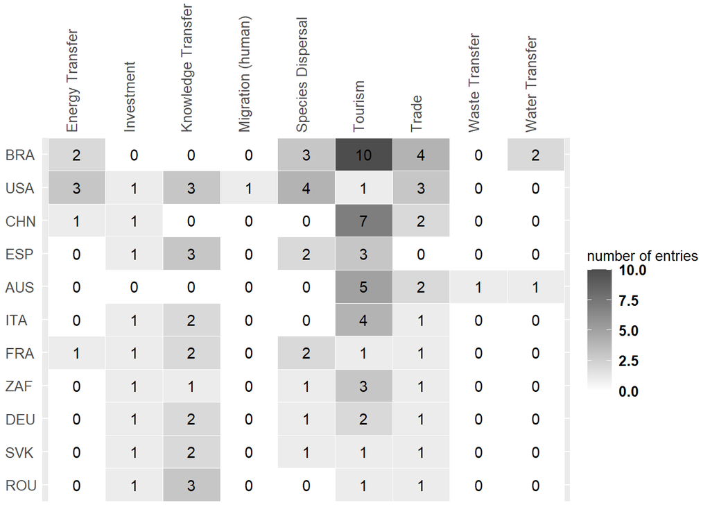

```r
## Percentage of telecoupling

k <- as.data.frame(cbind(df99$biodiv_countries, df99$tele_cat))
colnames(k) <- c('ctr', 'tc')

ctr_ls <- ctr_bio[1]

k$ctr[k$ctr == ""] <- NA

k$tc <- as.character(k$tc)

poo <- separate_rows(k, tc, sep=";", convert = TRUE)
doo <-separate_rows(poo, ctr, sep=";", convert = TRUE)


woo <- paste0(doo$ctr, '_', doo$tc)
woot <- as.data.frame(table(woo))

ok <- str_split_fixed(woot$woo, '_', 2)
woot$ctr <- ok[,1]
woot$tc <- ok[,2]


### count by ctr and tc
booty <- doo %>%
  dplyr::select(ctr, tc) %>%
  ### how many tcs in total for each ctr?
  ungroup() %>%
  group_by(ctr) %>%
  add_tally(name = 'total_tc') %>%
  ### the number of each tc
  dplyr::ungroup() %>%
  dplyr::group_by(ctr, total_tc) %>%
  dplyr::count(tc, name = 'n_tc') %>%
  arrange(ctr) %>%
  dplyr::mutate(pct_tc = n_tc/total_tc*100)


booty_check <-  booty %>%
  dplyr::group_by(ctr) %>%
  dplyr::summarise(sum = sum(pct_tc, na.rm = T))

booty2 <- booty[order(-booty$total_tc,booty$ctr, -booty$n_tc),]

# Load data of number of studies by taxa and flow
nr_ctr <- aggregate(x = booty2$n_tc,
                               by = list(booty2$ctr,booty2$tc),
                               FUN = sum)



# Rename columns

names(nr_ctr)[1:3] <- c("ctr","tc","count")

# Fill the gaps

mat_nr_ctr <-dcast(nr_ctr, ctr ~ tc, value.var = 'count')
filled_nr_ctr <- melt(mat_nr_ctr, id=c("ctr"))
filled_nr_ctr[is.na(filled_nr_ctr)] <- 0
names(filled_nr_ctr)[2:3] <- c("tc", "count")

# Subset for countries >5 total tc

filled_nr_ctr$n_tc <- booty2$total_tc[match(filled_nr_ctr$ctr, booty2$ctr)]
filled_nr_ctr<- filled_nr_ctr[which(filled_nr_ctr$n_tc > 5),]
filled_nr_ctr<-filled_nr_ctr[order(-filled_nr_ctr$n_tc),]


# Change order of factor levels for consistency with other figures

filled_nr_ctr$ctr <- factor(filled_nr_ctr$ctr,levels=c(unique(filled_nr_ctr$ctr[order(filled_nr_ctr$n_tc)])))

filled_nr_ctr$tc <- factor(filled_nr_ctr$tc,levels=c("Energy Transfer","Investment","Knowledge Transfer",
                                                      "Migration (human)","Migration (non-human)","Species Dispersal",
                                                      "Tourism","Trade","Waste Transfer","Water Transfer"))


# Heatmap plot


heatmap_ctr <- ggplot(filled_nr_ctr,
                      aes(x=tc, y=ctr, fill=count)) +
                      geom_tile(color = "white", size=0.25) +
                      geom_text(aes(label = count )) +
                      labs(x="",y="")+
                      scale_y_discrete(expand=c(0,0))+
                      theme_grey(base_size=8)+
                      scale_fill_gradientn(colours = c('#FFFFFF','gray30')) +
                      theme(legend.title = element_text(size = 10),
                      legend.text = element_text(size = 10, face="bold"),
                      plot.background=element_blank(),
                      plot.title = element_blank(),
                      axis.title= element_blank(),
                      axis.ticks = element_blank(),
                      axis.text.x.top = element_text(size=10, angle = 90, vjust=0,
                                                     hjust = 0),
                      axis.text.y.left = element_text(size=10, angle = 360, vjust=0.5,
                                                      hjust = 0),
                      strip.background = element_rect(fill="white"),
                      panel.spacing = unit(0.1, "lines")) +
                      scale_x_discrete(position = "top") +
                      labs(fill = "number of entries")

heatmap_ctr
```

# 5. Telecoupling Impact by Taxa

Note that there are five papers that reported more than one taxa. The maj_effect is not accurate for those five papers currently. This will be addressed soon.

```r
# get summary
  a <- ddply(s23_maj, .(taxa, maj_eff), summarize,
          # total count of entries
          count=length(taxa)) %>%
          # percents of effects within totals per taxa
          group_by(taxa) %>%
            nest() %>%
             mutate(perc_per_taxa=map(data, function(x) x$count/sum(x$count))) %>%
              unnest(cols = c(data, perc_per_taxa))
# save as csv
#  write.csv(a, paste0(tab.dir,'survey3_summary_effects_by_taxa.csv'),row.names = TRUE)

# Stack plot (count)
  quick_plot <- ggplot(a, aes(fill=maj_eff, y=count, x=taxa)) +
                geom_bar(position="stack", stat="identity") +
                theme_classic() +
                theme(axis.text.x = element_text(angle = 45, hjust = 1)) +
                scale_fill_manual(values=majeff_col) +
                xlab("")
```

```r
# Stack plot (percentage)
  quick_plot <- ggplot(a, aes(fill=maj_eff, y=perc_per_taxa, x=taxa)) +
                geom_bar(position="stack", stat="identity") +
                theme_classic() +
                theme(axis.text.x = element_text(angle = 45, hjust = 1)) +
                scale_fill_manual(values=majeff_col) +
                xlab("")
```

# 6. Telecoupling Impact by Habitat

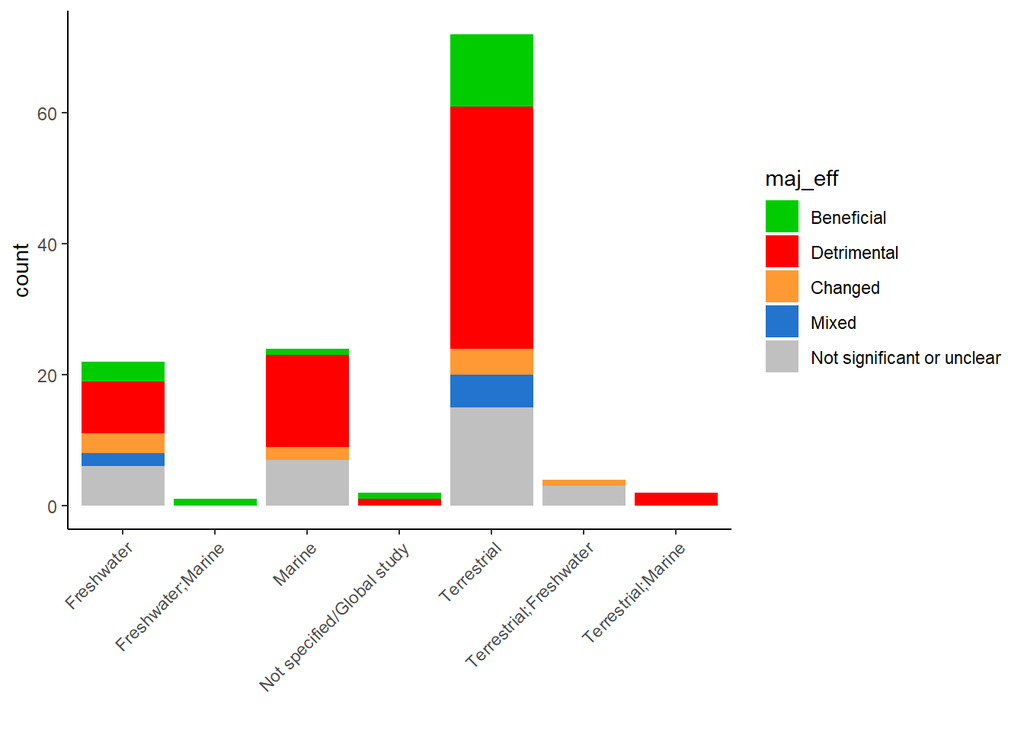

```r
# get summary
  a <- ddply(s23_maj, .(hab, maj_eff), summarize,
          # total count of entries
          count=length(hab)) %>%
          # percents of effects within totals per hab
          group_by(hab) %>%
            nest() %>%
             mutate(perc_per_hab=map(data, function(x) x$count/sum(x$count))) %>%
              unnest(cols = c(data, perc_per_hab))
# save as csv
#  write.csv(a, paste0(tab.dir,'survey3_summary_effects_by_hab.csv'), row.names = TRUE)

# Stack plot (count)
  quick_plot <- ggplot(a, aes(fill=maj_eff, y=count, x=hab)) +
                geom_bar(position="stack", stat="identity") +
                theme_classic() +
                theme(axis.text.x = element_text(angle = 45, hjust = 1)) +
                scale_fill_manual(values=majeff_col) +
                xlab("")

# view
  quick_plot
```

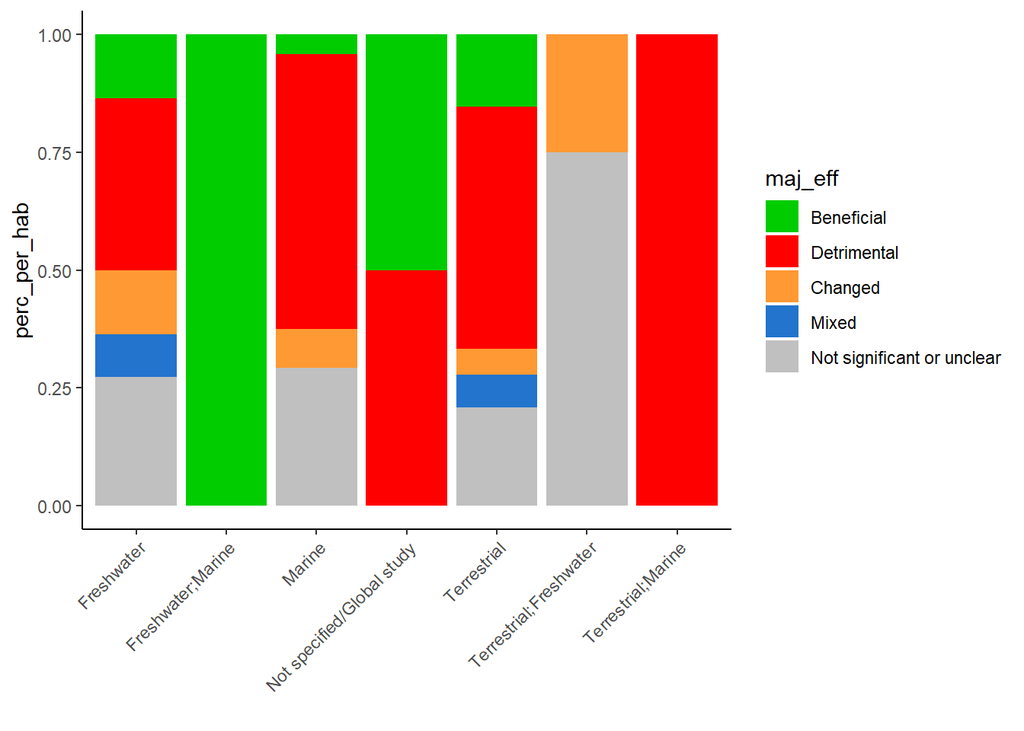

```r
# Stack plot (percent)
  quick_plot <- ggplot(a, aes(fill=maj_eff, y=perc_per_hab, x=hab)) +
                geom_bar(position="stack", stat="identity") +
                theme_classic() +
                theme(axis.text.x = element_text(angle = 45, hjust = 1)) +
                scale_fill_manual(values=majeff_col) +
                xlab("")
quick_plot
```

# 7. Telecoupling Impact by Flow

Duplicate rows with multiple flow types. This means that effects and other results will be *duplicated* as well.

The reason for doing this is so that we can attribute biodiversity impacts to the specific flows that may have been studied together, and whose individual impacts cannot be decoupled.

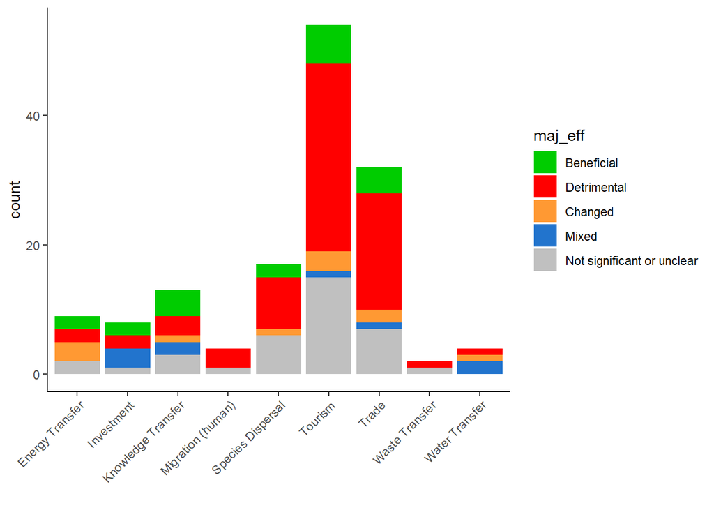

```
## [1] "Original number of rows: 127"
## [1] "Number of rows after separating multiple flows per paper: 143"
```

```r
# set as character
  s23_maj$tc <- as.character(s23_maj$tc)

# show original length of rows
  print(paste('Original number of rows:',nrow(s23_maj)))

# split multiple flows listed in a row into other new rows
  tcRep_maj <- separate_rows(s23_maj, tc, sep=";", convert = TRUE)
  tcRep_maj$tc <- as.factor(tcRep_maj$tc)

# show new length of rows
  print(paste('Number of rows after separating multiple flows per paper:',nrow(tcRep_maj)))

# show levels
#  summary(tcRep$tc)

# get summary
  a <- ddply(tcRep_maj, .(tc, maj_eff), summarize,
          # total count of entries
          count=length(tc)) %>%
          # percents of effects within totals per tc
          group_by(tc) %>%
            nest() %>%
             mutate(perc_per_tc=map(data, function(x) x$count/sum(x$count))) %>%
              unnest(cols = c(data, perc_per_tc))
# save as csv
#  write.csv(a, paste0(tab.dir,'survey3_summary_effects_by_flow.csv'),row.names = TRUE)

# Stack plot (count)
  quick_plot <- ggplot(a, aes(fill=maj_eff, y=count, x=tc)) +
                geom_bar(position="stack", stat="identity") +
                theme_classic() +
                theme(axis.text.x = element_text(angle = 45, hjust = 1)) +
                scale_fill_manual(values=majeff_col) +
                xlab("")


# view
  quick_plot
```

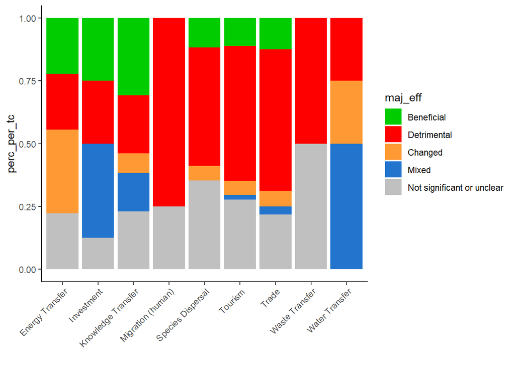

```r
# Stack plot (percent)
  quick_plot <- ggplot(a, aes(fill=maj_eff, y=perc_per_tc, x=tc)) +
                geom_bar(position="stack", stat="identity") +
                theme_classic() +
                theme(axis.text.x = element_text(angle = 45, hjust = 1)) +
                scale_fill_manual(values=majeff_col) +
                xlab("")

quick_plot
```

# 8. Telecoupling impacts by metric type and flow

Replicate TC flows by entry

```r
# set as character
  s23$tc <- as.character(s23$tc)
  poo<-s23[is.na(s23$tc),]


# show original length of rows
  print(paste('Original number of rows:',nrow(s23)))

# split multiple flows listed in a row into other new rows
  tcRep <- separate_rows(s23, tc, sep=";", convert = TRUE)
  tcRep$tc <- as.factor(tcRep$tc)

# show new length of rows
  print(paste('Number of rows after separating multiple flows per paper:',nrow(tcRep)))

  tcRep_maj <- tcRep[!duplicated(tcRep$paper_id),]
```

```
## [1] "Original number of rows: 731"
## [1] "Number of rows after separating multiple flows per paper: 771"
```

Convert to long format, where metric is indicated.

```r
# subset
  metrics <- subset(tcRep,
                    select=c('paper_id','entry_id',
                            'taxa','tc','sig_effect',
                            'biodiv_cat_1sp',
                            'biodiv_cat_multsp',
                            'biodiv_cat_habitat'))
# melt
  metrics_long <- melt(metrics, id.vars=c('paper_id','entry_id',
                            'taxa','tc','sig_effect'))

# remove NA fields
  metrics_long <- metrics_long[!is.na(metrics_long$value),]

# change colnames
  colnames(metrics_long)[6] <- 'metric_type'
  colnames(metrics_long)[7] <- 'metric'


# change levels
  levels(metrics_long$metric_type) <- c('Single species',
                                        'Multiple species',
                                        'Habitat')

  levels(as.factor(metrics_long$metric))

# remove parentheses
  metrics_long$metric <- gsub("\\s*\\([^\\)]+\\)", '',
                          as.character(metrics_long$metric))

# capitalize each word
  metrics_long$metric <- tools::toTitleCase(metrics_long$metric)

# adjust name
  metrics_long$metric <- gsub("With-in", 'Within',
                        as.character(metrics_long$metric))

# change levels, moving other to the end
  metrics_long$metric <- factor(metrics_long$metric,
                                c("Abundance/Density",
                                   "Amount",
                                   "Composition",
                                   "Detection",
                                   "Diversity Index",
                                   "Evenness",
                                   "Movement",
                                   "Occurrence",
                                   "Population Dynamics",
                                   "Quality",
                                   "Richness",
                                   "Within Species Diversity"
                                  ))

# check levels
  levels(as.factor(metrics_long$metric))

# get summary
  metric_flow <- ddply(metrics_long,
                       .(metric_type, metric, tc, sig_effect),
                       summarize,
                      # total count of entries
                        count=length(metric))

# save as csv
#  write.csv(metric_flow, paste0(tab.dir,'synthesis_sig_effects_metric_and_flow.csv'),row.names = TRUE)

# sig_effects level change
  metric_flow$sig_effect <- gsub("\\s*\\([^\\)]+\\)", '',
                          as.character(metric_flow$sig_effect))
  metric_flow$sig_effect <- factor(metric_flow$sig_effect,
                             c( "Beneficial","Detrimental","Changed","Not significant or unclear"))
# telecoupling level change
  metric_flow$tc <- factor(metric_flow$tc,
                                c("Energy Transfer","Investment","Knowledge Transfer",
                                 "Migration (human)","Migration (non-human)",
                                 "Species Dispersal","Tourism","Trade","Waste Transfer","Water Transfer"
                                ))
```

```
##  [1] "Abundance/Density (biomass, mass, number of individuals, individuals/unit area)"
##  [2] "Abundance/Density (number of individuals, individuals/unit area, biomass)"
##  [3] "Amount (e.g. land use change from non-habitat to habitat)"
##  [4] "Composition (what species?)"
##  [5] "Diversity index (Shannon-Weiner, Simpson's, Inverse Simpson's, etc.)"
##  [6] "Evenness"
##  [7] "Movement"
##  [8] "Occurrence"
##  [9] "Occurrence (presence, range, persistence, etc., NOT detection)"
## [10] "Population dynamics (survival, fitness, reproduction, mortality, etc.)"
## [11] "Quality (pollution, connectence, disturbance, etc.)"
## [12] "Richness (number of species)"
## [13] "With-in species diversity (genetic diversity, age structure, etc.)"
##  [1] "Abundance/Density"        "Amount"
##  [3] "Composition"              "Detection"
##  [5] "Diversity Index"          "Evenness"
##  [7] "Movement"                 "Occurrence"
##  [9] "Population Dynamics"      "Quality"
## [11] "Richness"                 "Within Species Diversity"
```

Figure code

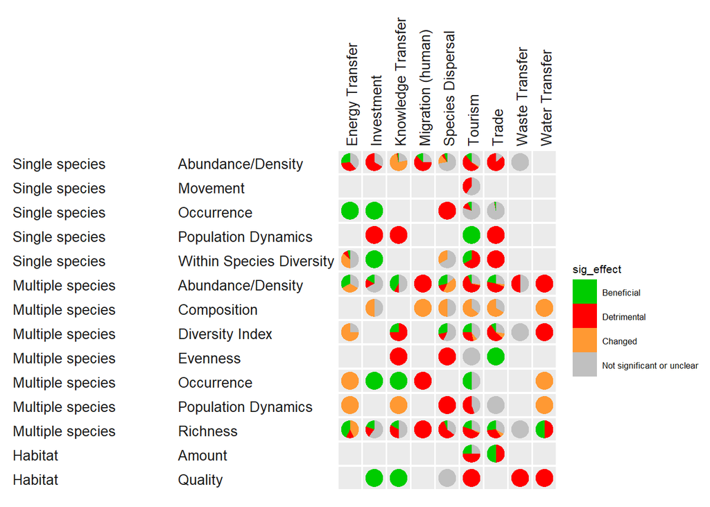

```r
# Matrix of pie charts
  sig_effect_cols <- sigeff_col

  metric_flow_fig <- ggplot(metric_flow) +
                    aes(x='', y = count, fill = sig_effect) +
                    geom_bar(position='fill',
                             stat='identity', width = 1, size = 0.01) +
                    # activate for vertical or horizontal version
                      facet_grid(metric_type ~ metric ~ tc, switch='y') + #horizontal
                      #facet_grid(tc ~ metric, switch='y') +  #vertical
                    # convert to pie chart
                      coord_polar(theta = 'y') +
                    # colors
                      scale_fill_manual(
                        values=sig_effect_cols,
                        guide = guide_legend(reverse = FALSE))  +
                        scale_y_discrete(position='right',expand=c(0,0))+
                    # style
                      theme_gray(base_size=8)+
                      theme(
                        axis.title=element_blank(),
                        axis.line=element_blank(),
                        axis.ticks=element_blank(),
                        axis.text=element_blank(),
                        panel.border = element_blank(),
                        panel.grid=element_blank(),
                        panel.grid.major = element_blank(),
                        panel.grid.minor = element_blank(),
                        plot.background = element_rect(),
                        plot.title=element_blank(),
                        strip.text.x = element_text(size=10,
                                          angle=90, vjust=0, hjust = 0),
                        strip.text.y.left = element_text(size=10,
                                          angle=0, vjust=0, hjust = 0),
                        strip.background = element_rect(fill='white'),
                        panel.spacing = unit(0.1, 'lines')
                        ) +
                    # labels
                      ylab('') + xlab('')



# display image
  metric_flow_fig
```

Heatmap

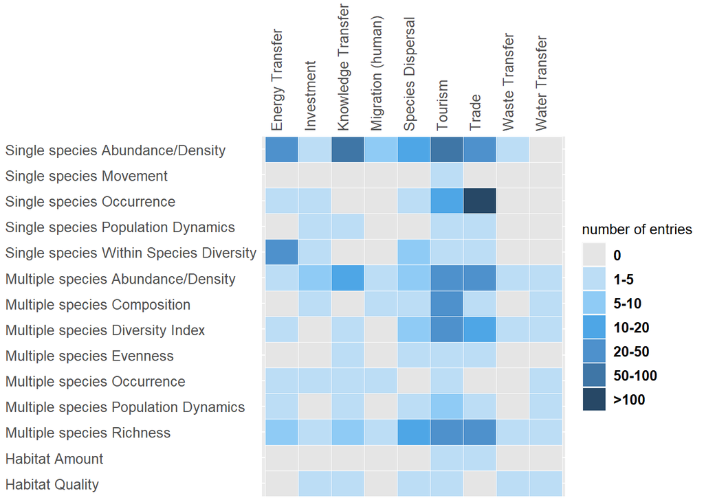

```r
# Load data of number of studies by taxa and flow
nr_metric_tele <- aggregate(x = metric_flow$count,
                               by = list(metric_flow$metric_type,metric_flow$metric, metric_flow$tc),
                               FUN = sum)



# Rename columns

names(nr_metric_tele)[1:4] <- c("type","metric", "telecoupling", "count")

nr_metric_tele$metricType <- paste(nr_metric_tele$type,nr_metric_tele$metric)

# Fill the gaps

mat_nr_metric_tele <-dcast(nr_metric_tele, metricType ~ telecoupling, value.var = 'count')
filled_nr_metric_tele <- melt(mat_nr_metric_tele, id=c("metricType"))
filled_nr_metric_tele[is.na(filled_nr_metric_tele)] <- 0
names(filled_nr_metric_tele)[2:3] <- c("telecoupling", "count")

# Create 'count' categories for representation

filled_nr_metric_tele$count_factor <- cut(filled_nr_metric_tele$count,
                                          breaks = c(-1,0,5,10,20,50,100,max(filled_nr_metric_tele$count,na.rm=T)),
                                          labels=c("0","1-5","5-10","10-20","20-50","50-100",">100"))


# Change order of factor levels for consistency with other figures

filled_nr_metric_tele$metricType <- as.character(filled_nr_metric_tele$metricType)

filled_nr_metric_tele$metricType <- factor(filled_nr_metric_tele$metricType,
          levels=c("Habitat Quality",
                   "Habitat Amount",
                   "Multiple species Richness",
                   "Multiple species Population Dynamics",
                   "Multiple species Occurrence",
                   "Multiple species Evenness",
                   "Multiple species Diversity Index",
                   "Multiple species Composition",
                   "Multiple species Abundance/Density",
                   "Single species Within Species Diversity",
                   "Single species Population Dynamics",
                   "Single species Occurrence",
                   "Single species Movement",
                   "Single species Abundance/Density"
          ))
# Heatmap plot

heatmap_telemetric <- ggplot(filled_nr_metric_tele,
                      aes(x=telecoupling, y=metricType, fill=count_factor)) +
                      geom_tile(color = "white", size=0.25) +
                      scale_fill_manual(values=c("grey90","#BCDDF5","#8FCBF5","#4EA6E6",
                                               "#4E91CC","#3F76A6","#274866"))+
                      labs(x="",y="")+
                      scale_y_discrete(expand=c(0,0))+
                      theme_grey(base_size=8)+

                      theme(legend.title = element_text(size = 10),
                      legend.text = element_text(size = 10, face="bold"),
                      plot.background=element_blank(),
                      plot.title = element_blank(),
                      axis.title= element_blank(),
                      axis.ticks = element_blank(),
                      axis.text.x.top = element_text(size=10, angle = 90, vjust=0,
                                                     hjust = 0),
                      axis.text.y.left = element_text(size=10, angle = 360, vjust=0.5,
                                                      hjust = 0),
                      strip.background = element_rect(fill="white"),
                      panel.spacing = unit(0.1, "lines")) +
                      scale_x_discrete(position = "top") +
                      labs(fill = "number of entries")

heatmap_telemetric
```